# 2D Visualization Example

## Outline

2D Visualization Class

Lidar Visualization

Annotations Visualizations

Combined Visualization

## Loading frame information

This step is required to use the frame transformations class. The content of this snippet is explained in Notebook 1.

```python
from vod.configuration import KittiLocations
from vod.frame import FrameDataLoader


kitti_locations = KittiLocations(root_dir="example_set",
                                output_dir="example_output")

frame_data = FrameDataLoader(kitti_locations=kitti_locations,
                             frame_number="01201")
```

## 2D Visualization class

The `Visualization2D` class allows the projection of the lidar, radar data, and the 3D-boxes of the annotation to the camera picture. The example below shows the instantiation of the class, and applies the `draw_plot()` to plot the picture.

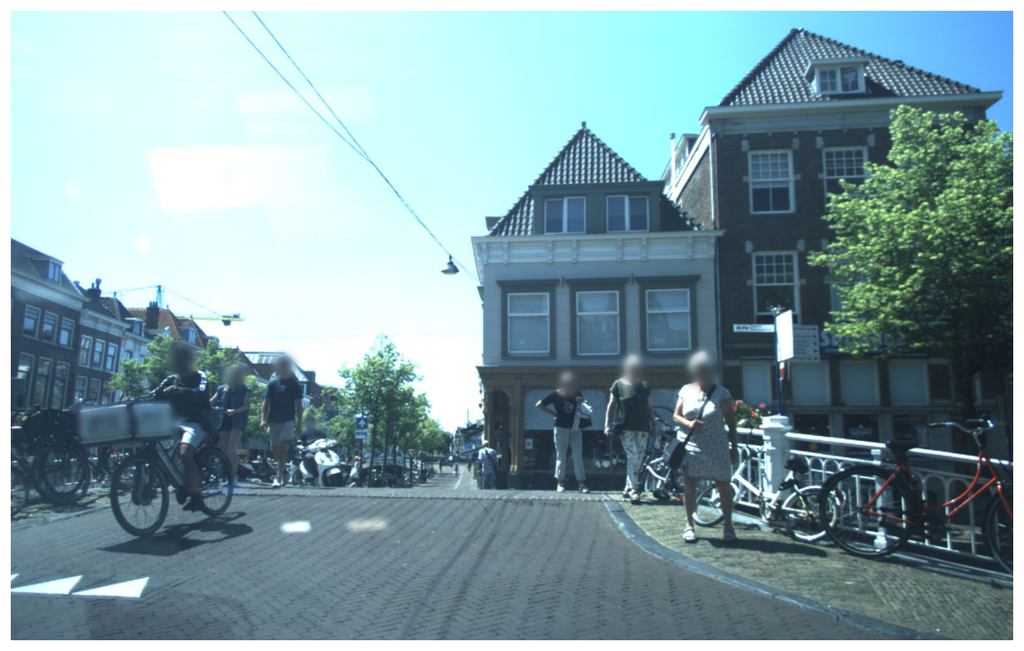

```python
from vod.visualization import Visualization2D

vis2d = Visualization2D(frame_data)

vis2d.draw_plot()
```

## LIDAR point-cloud visualization

By changing the arguments of the `draw_plot()` method, plotting lidar points is also possible.

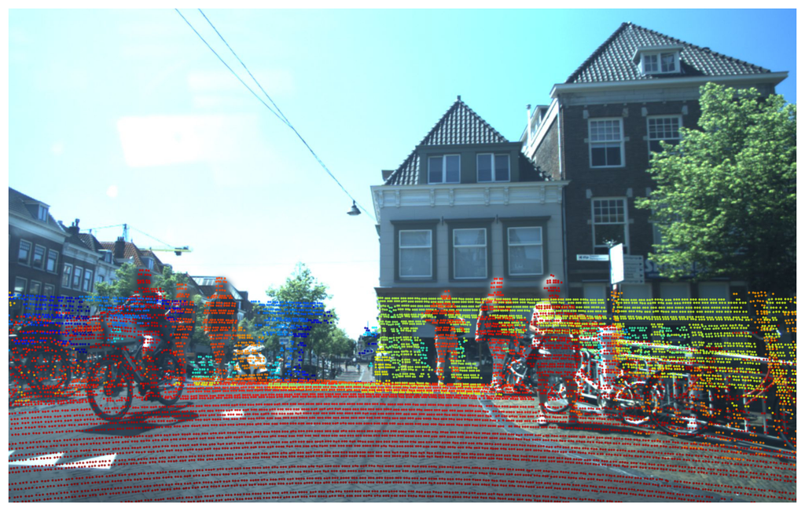

```python
vis2d.draw_plot(show_lidar=True)
```

## Radar point-cloud visualization

Similar to Lidar, provided `show_radar=True` argument, the radar pcl can be also plotted over the picture.

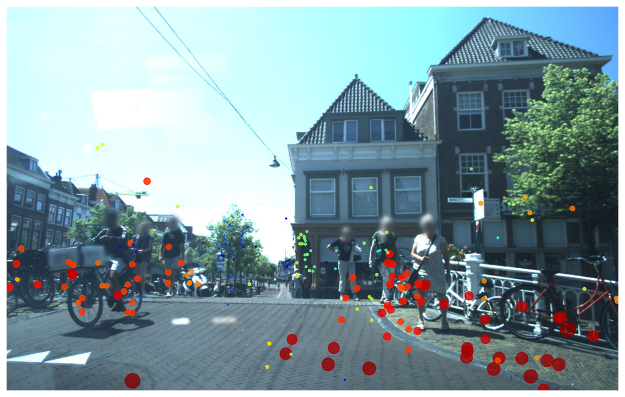

```python
vis2d.draw_plot(show_radar=True)
```

## Annotation visualization

Similar to point-cloud data, the 3D bounding boxes can be also plotted over the picture.

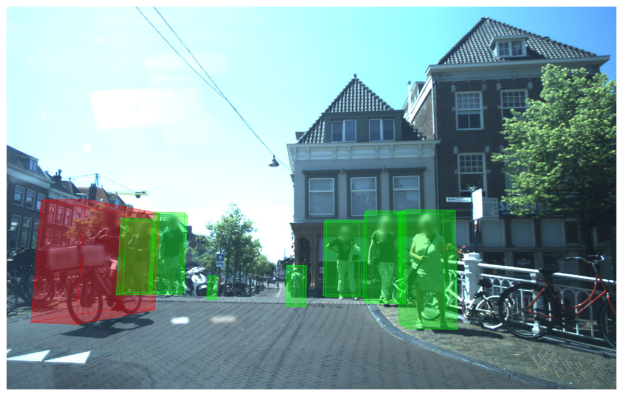

```python
vis2d.draw_plot(show_gt=True)
```

## 2D Combined sensors and filters

Plotting the point-clouds and the annotations in a single plot is also possible. It is also possible to set filters for distance, which limits the number of plotted instances. Using the `save_figure` argument, it is possible to save the image to a file as well.

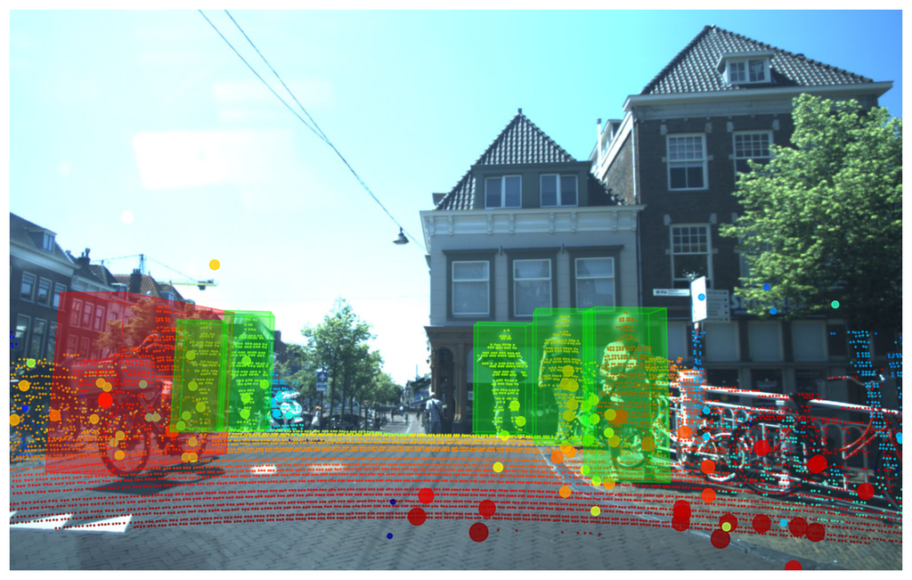

```python
vis2d.draw_plot(show_lidar=True,
                             show_radar=True,
                             show_gt=True,
                             min_distance_threshold=5,
                             max_distance_threshold=20,
                             save_figure=True)
```